# Python for A-Level Mathematics and Beyond

Homepage: https://www.mmu.ac.uk/computing-and-maths/staff/profile/dr-stephen-lynch

[figure not shown]

# Introduction

This notebook lists examples of simple Python commands and programs that can be used to help with the understanding of the new A-Level syllabus. Teachers can use the examples to help with teaching or to make up examples and exercises. Pupils can use Python to check their answers and learn programming to help with employability. As you will discover, Python can help with all of the MEI schemes of work listed in the table above.

This is a Jupyter notebook launched from within the Anaconda data science platform. Anaconda can be downloaded here:

https://www.anaconda.com

Python is an open-source programming language used extensively around the world. It is also vital for carrying out Scientific Computation!

To execute commands in Jupyter, either Run the cell or hit SHIFT + ENTER.

More information on why you should learn Python is given here: [Python for A-Level Maths, Undergraduate Maths and Employability](https://www.mathscareers.org.uk/python-for-a-level-maths-undergraduate-maths-and-employability/)

Alternatively, you can perform cloud computing using Google Colab:

https://colab.research.google.com/

You will need a Google account to perform cloud computing.

# 1. Surds and Indices

From the sympy module import sqrt and simplify.

(i) Simplify $(2 + 2 \sqrt{2})(-\sqrt{2} + 4)$.

(ii) Simplify $\frac{6}{5 \sqrt{2}}$ and $\frac{1}{2-\sqrt{5}}$

(iii) Expand $(2-3 \sqrt{5})^{10}$. Do not do this by hand!

```python
# Load functions from the SYMbolic PYthon module.
from sympy import sqrt, simplify
simplify((2 + 2 * sqrt(2))*(-sqrt(2) + 4))
```

$\displaystyle 4 + 6 \sqrt{2}$

```python
print(simplify(6 / (5 * sqrt(2))))

print(simplify(1 / (2 - sqrt(5))))
```

```
3*sqrt(2)/5
-sqrt(5) - 2
```

```python
simplify((2 - 3 * sqrt(5))**10)
```

$\displaystyle 1256556049 - 559555260 \sqrt{5}$

Find, to 3 significant figures, the value of $x$ for which $8^x=0.8$.

```python
from sympy import Symbol, solve
x = Symbol('x')
sol = solve(8**x - 0.8, x)
# Zero-based indexing in Python: sol[0] is the first solution.
# The other two roots are complex.
# Format the solution.
print('The real solution is {:0.3g},'.format(sol[0]), 'to 3 sig. figs.')
```

```
The real solution is -0.107, to 3 sig. figs.
```

# 2. Quadratic Functions

From sympy import solve and Symbol. Import numpy and matplotlib.

(i) Determine the roots of the equation: $x^2+3x-5=0$.

(ii) Plot the quadratic function: $y=x^2+3x-5$.

```python
from sympy import solve, Symbol
x = Symbol('x')
solve(x**2 + 3 * x - 5, x)
```

```
[-3/2 + sqrt(29)/2, -sqrt(29)/2 - 3/2]
```

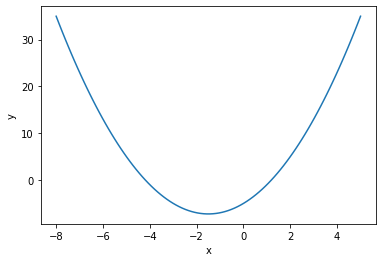

```python
# Use the alias np instead of numpy (NUMerical PYthon).
# Use the alias plt for matplotlib.pyplot.
import numpy as np
import matplotlib.pyplot as plt
# x ranges from -8 to 5 in 100 intervals.
x = np.linspace(-8, 5, 100)
plt.plot(x, x**2 + 3 * x - 5)
plt.xlabel('x')
plt.ylabel('y')
# Show the plot.
plt.show()
```

# 3. Equations and Inequalities

(i) Solve the simultaneous equations: $2x+y=4, x^2-y=4$.

(ii) Solve the inequality $x^2-4x+1 \geq x-3$.

```python
from sympy import solve, symbols
x, y = symbols('x, y')
solve((2 * x + y - 4, x**2 - y - 4), x, y)
```

```
[(-4, 12), (2, 0)]
```

```python
solve(x**2 - 4 * x + 1 >= x - 3, x)
```

$\displaystyle \left(4 \leq x \wedge x < \infty\right) \vee \left(x \leq 1 \wedge -\infty < x\right)$

# 4. Coordinate Geometry

Plot a tangent to a circle.

(i) Plot the circle $x^2+y^2-2x-2y-23=0$.

(ii) Plot the line $4x-3y-26=0$.

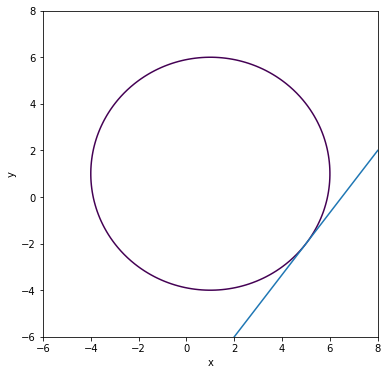

```python
import numpy as np
import matplotlib.pyplot as plt
# Set the dimensions of the figure.
fig = plt.figure(figsize = (6, 6))
x, y = np.mgrid[-6:8:100j,-6:8:100j]
z = x**2 + y**2 - 2 * x - 2 * y
# You can plot multiple contours if desired.
plt.contour(x, y, z, levels = [23])
x = np.linspace(2, 8, 100)
y = (4 * x - 26) / 3
plt.plot(x, y)
plt.xlabel('x')
plt.ylabel('y')
plt.show()
```

# 5. Trigonometry

Plot the trigonometric functions $y=2\sin(3t)$ and $y=3\cos(2t-\pi)$ on one graph.

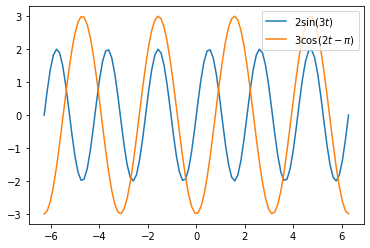

```python
import numpy as np
import matplotlib.pyplot as plt
t = np.linspace(-2 * np.pi, 2 * np.pi, 100)
# LaTeX code in labels.
plt.plot(t, 2 * np.sin(3 * t), label = '$2\sin(3t)$')
plt.plot(t, 3 * np.cos(2 * t - np.pi), label ='$3\cos(2t-\pi)$')
legend = plt.legend()
plt.show()
```

# 6. Polynomials

(i) Factorize $2x^4-x^3-4x^2-5x-12$.

(ii) Expand $\left(x^2-x+1\right)\left(x^3-x^2+x\right)$.

```python
from sympy import expand, factor, Symbol
x = Symbol('x')
p1 = factor(2 * x**4 - x**3 - 4 * x**2 - 5 * x - 12)
p2 = expand((x**2 - x + 1) * (x**3 - x**2 + x))
print(p1)
print(p2)
```

```
(2*x + 3)*(x**3 - 2*x**2 + x - 4)
x**5 - 2*x**4 + 3*x**3 - 2*x**2 + x
```

# 7. Graphs and Transformations

Plot the trigonometric functions $y_1=sin(t)$ and $y_2=2+2sin(3t+\pi)$ on one graph.

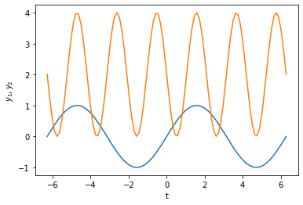

```python
import numpy as np
import matplotlib.pyplot as plt
t = np.linspace(-2 * np.pi, 2 * np.pi, 100)
plt.plot(t, np.sin(t), t, 2 + 2 * np.sin(3 * t + np.pi))
plt.xlabel('t')
# LaTeX code in ylabel.
plt.ylabel('$y_1, y_2$')
plt.show()
```

# Animation

Produce an animation of the sine wave, $y=\sin(\omega t)$, for $0 \leq \omega \leq 10$. In this case, the frequency of the sine wave is changing. A slider appears under the figure. You can set the animation to Reflect to see how the curve changes as a parameter increases and decreases.

```python
import numpy as np
from matplotlib import pyplot as plt
from matplotlib import animation

fig = plt.figure()
ax = plt.axes(xlim=(0, 2),ylim=(-2, 2))
line, = ax.plot([],[],lw=2)
plt.xlabel('time')
plt.ylabel('sin($\omega$t)')
plt.close()

def init():
    line.set_data([],[])
    return line,

# The function to animate.
# frames = 101, so 0 <= i <= 100.
def animate(i):
    x = np.linspace(0, 2, 1000)
    y = np.sin((0.1 * i * x))
    line.set_data(x, y)
    return line,

# Note: blit=True means only re-draw the parts that have changed.
anim = animation.FuncAnimation(fig, animate, init_func=init, \
                               frames=101, interval=200, blit=False)

# The code to produce an animation in html.
from IPython.display import HTML
HTML(anim.to_jshtml())
```

[figure not shown]

Once Loop Reflect

# Interactive plot

The amplitude $A$ varies $0 \leq A \leq 5$, in steps of $0.2$, the frequency $B$ varies $0 \leq B \le 2\pi$, the phase $C$ varies $0 \leq C \leq 2\pi$ and the vertical shift $D$ varies $-3 \leq D \leq 3$, in steps of $0.5$.

[figure not shown]

```python
# Interactive plots with Python.
from __future__ import print_function
from ipywidgets import interact, interactive, fixed, interact_manual
import ipywidgets as widgets

%matplotlib inline
from ipywidgets import interactive
import matplotlib.pyplot as plt
import numpy as np

# Interactive plot showing amplitude, frequency, phase and vertical shift.

def f(A, B, C, D):
    plt.figure(2)
    x = np.linspace(-10, 10, num=1000)
    plt.plot(x, A * np.sin(B * (x + C)) + D)
    plt.ylim(-8, 8)
    plt.show()

interactive_plot = interactive(f, A = (0, 5, 0.2), B = (0, 2 * np.pi), \
                               C = (0, 2 * np.pi),  D = (-3, 3, 0.5))
output = interactive_plot.children[-1]
output.layout.height = '350px'
interactive_plot
```

```
interactive(children=(FloatSlider(value=2.0, description='A', max=5.0, step=0.2), FloatSlider(value=3.14159265…
```

# 8. The Binomial Expansion

(i) Expand $(1-2x)^6$.

(ii) Plot the graph of $B(n)=\left(1+\frac{1}{n} \right)^n$.

```
(1 - 2 * x)**6 = 64*x**6 - 192*x**5 + 240*x**4 - 160*x**3 + 60*x**2 - 12*x + 1
```

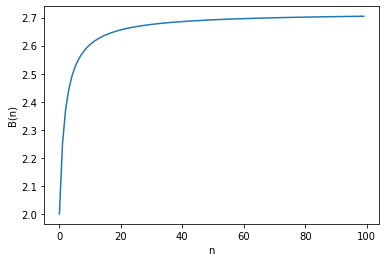

```python
from sympy import expand, Symbol
import numpy as np
import matplotlib.pyplot as plt
x = Symbol('x')
p1 = expand((1 - 2 * x)**6)
print("(1 - 2 * x)**6 =", p1)
n = np.linspace(1, 100, 100)
plt.plot((1 + 1/ n)**n)
plt.xlabel('n')
plt.ylabel('B(n)')
plt.show()
```

# 9. Differentiation

Determine:

(i) the first derivative of $x^3 + 3x^2 - 7x + 5$;

(ii) the second derivative of $4x^3 - 3x^4$.

```python
from sympy import diff, Symbol
x = Symbol('x')
d1 = diff(x**3 + 3 * x**2 - 7 * x + 5, x)
print(d1)
d2 = diff(4 * x**3 - 3 * x**4, x, 2)
print(d2)
```

```
3*x**2 + 6*x - 7
12*x*(2 - 3*x)
```

# 10. Integration

Determine:

(i) the indefinite integral $I_1 = \int x^4+3x^3-8 dx$;

(ii) the definite integral $I_2 = \int_{x=0}^{\pi} sin(x)cos(x) dx$.

```python
from sympy import *
x = Symbol('x')
i1 = integrate(x**4 + 3 * x**3 - 8)
print('I_1 =', i1, "+ c")
i2 = integrate(sin(x) * cos(x), (x, 0, pi))
print('I_2 =',i2)
```

```
I_1 = x**5/5 + 3*x**4/4 - 8*x + c
I_2 = 0
```

# 11. Vectors

Given that $\underline{u}=(1, 3)$ and $\underline{v}=(3, -5)$, determine:

(i) $\underline{w}=2\underline{u}+3\underline{v}$;

(ii) the distance between $\underline{u}$ and $\underline{v}$, $d=\| \underline{u}-\underline{v} \|$.

The length of the vector $\underline{u}=\left( u_1,u_2 \right)$, or the norm of $\underline{u}$, is defined to be $\|\underline{u} \|=\sqrt{u_1^2+u_2^2}$.

```python
import numpy as np
u = np.array([1, 3])
v = np.array([3, -5])
w = 2 * u + 3 * v
print("w =", w)
d = np.linalg.norm(u - v)
print("d =", d)
```

```
w = [11 -9]
d = 8.246211251235321
```

# 12. Exponentials and Logarithms

(ii) Plot the graph, $x=1-e^{-t}$.

(iii) Solve the equation $7^{x-3}=4$.

```
exp(10) = 22026.465794806718
log(22026.4658) = 10.000000000235774
```

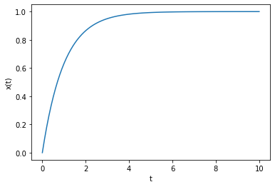

```
The solution to 7**{x-3}=4 is, [log(1372)/log(7)]
```

```python
import numpy as np
import matplotlib.pyplot as plt
exp10 = np.exp(10)
print("exp(10) =", exp10)
log10 = np.log(22026.4658)
print("log(22026.4658) =", log10)
t = np.linspace(0, 10, 100)
x = 1 - np.exp(- t)
plt.plot(t, x)
plt.xlabel('t')
plt.ylabel('x(t)')
plt.show()

from sympy import Symbol
x = Symbol('x')
sol = solve(7**(x-3) - 4)
print('The solution to', '7**{x-3}=4 is,', sol)
```

# 13. Data Collection

(i) Select 10 random numbers from a list of the first 25 natural numbers.

```python
import math, random, statistics
a = list(range(1, 26))
data1 = random.sample(a, 10)
print("data1 =", data1)
b = list(range(2, 102, 2))
data2 = random.sample(b, 10)
print("data2 =", data2)
```

```
data1 = [22, 15, 21, 4, 5, 25, 9, 20, 19, 23]
data2 = [88, 22, 10, 34, 100, 58, 56, 42, 48, 24]
```

# 14. Data Processing

Determine the mean, median, mode, variance and standard deviation of the data set:

[43, 39, 41, 48, 49, 56, 55, 44, 44, 32, 20, 44, 48, 2, 98].

```python
import statistics as stats
data1 = [43, 39, 41, 48, 49, 56, 55, 44, 44, 32, 20, 44, 48, 2, 98]
mean_data1 = stats.mean(data1)
print("mean_data1 =", mean_data1)
median_data1 = stats.median(data1)
print("median_data1 =", median_data1)
mode_data1 = stats.mode(data1)
print("mode_data1 =", mode_data1)
var_data1 = stats.variance(data1)
print("var_data1 =", var_data1)
stdev_data1 = stats.stdev(data1)
print("stdev_data1 =", stdev_data1)
```

```
mean_data1 = 44.2
median_data1 = 44
mode_data1 = 44
var_data1 = 411.1714285714286
stdev_data1 = 20.277362465849166
```

# 15. Probability

Plot a Venn diagram for the following data. The following shows the results of a survey on the types of exercises taken by a group of 100 pupils: 65 run, 48 swim, 60 cycle, 40 run and swim, 30 swim and cycle, 35 run and cycle and 25 do all 3. Draw a Venn diagram to represent these data.

Let A denote the set of pupils who run, B represent the set of pupils who swim and C contain the set of pupils who cycle.

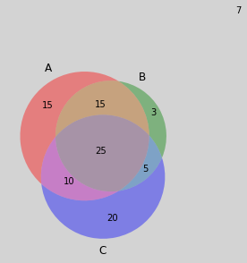

```python
# Venn Diagram.
# Install the matplotlib-venn library on to your computer.
# In the Terminal type: conda install -c conda-forge matplotlib-venn
# Alternatively, run the code in Google Colab.
import matplotlib.pyplot as plt
import numpy as np
from matplotlib_venn import venn3
fig, ax = plt.subplots(facecolor='lightgray')
ax.axis([0, 1, 0, 1])
v = venn3(subsets = (15, 3, 15, 20, 10, 5, 25))
ax.text(1, 1, "7")
plt.show()
```

# 16. The Binomial Distribution

The binomial distribution is an example of a discrete probability distribution function.

Given $X \sim B(n,p)$, then $P(X=r)={n \choose r}p^r(1-p)^{n-r}$,

where $X$ is a binomial random variable, and $p$ is the probability of $r$ success from $n$ independent trials. Note that (i) the expectation, $E(X)=np$; (ii) the variance, $\mathrm{var}(X)=np(1-p)$; and (iii) the standard deviation, $\mathrm{std}=\sqrt{np(1-p)}$.

Example: Manufacturers of a bag of sweets claim that there is a 90% chance that the bag contains some toffees. If 20 bags are chosen, what is the probability that:

(a) All bags contain toffees?

(b) More than 18 bags contain toffees?

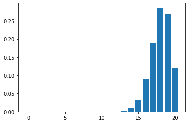

```
Mean =  18.0
Variance =  1.7999999999999996
Standard Deviation =  1.3416407864998736
P(X=20)= 0.12157665459056931
P(X>18)= 0.3917469981251682
```

```python
from scipy.stats import binom
import matplotlib.pyplot as plt
n , p = 20 , 0.9
r_values = list(range(n+1))
dist = [binom.pmf(r , n , p) for r in r_values]
plt.bar(r_values , dist)
plt.show()
print('Mean = ', binom.mean(n = 20 , p = 0.9))
print('Variance = ', binom.var(n = 20 , p = 0.9))
print('Standard Deviation = ', binom.std(n = 20 , p = 0.9))

PXis20 = binom.pmf(20, n, p)      # Probability mass function.
print('P(X=20)=' , PXis20)
PXGT18 = 1 - binom.cdf(18, n, p)  # Cumulative distribution function.
print('P(X>18)=' , PXGT18 )       # P(X>18)=1-P(X<=18).
```

# 17. Hypothesis Testing

Example: The probability of a patient recovering from illness after taking a drug is thought to be 0.85. From a trial of 30 patients with the illness, 29 recovered after taking the drug. Test, at the 10% level, whether the probability is different to 0.85.

So, $H_0=0.85$,

$H_1 \neq 0.85$. (Two-tail test)

The program below gives $P(X \geq 29)=0.0480<0.05$.

Therefore, the result is significant and so we reject $H_0$. There is evidence to suggest that the probability of recovery from the illness after taking the drug is different to 0.85.

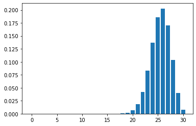

```
Mean =  25.5
Variance =  3.8250000000000006
Standard Deviation =  1.9557607215607948
P(X>=29)= 0.04802889862602788
```

```python
from scipy.stats import binom
import matplotlib.pyplot as plt
n , p = 30 , 0.85
r_values = list(range(n+1))
dist = [binom.pmf(r , n , p) for r in r_values]
plt.bar(r_values , dist)
plt.show()
print('Mean = ', binom.mean(n = 30 , p = 0.85))
print('Variance = ', binom.var(n = 30 , p = 0.85))
print('Standard Deviation = ', binom.std(n = 30 , p = 0.85))
PXGTE29 = 1 - binom.cdf(28, n, p)  # Cumulative distribution function.
print('P(X>=29)=' , PXGTE29 )      # P(X>=29)=1-P(X<=28).
```

# 18. Kinematics

Plot a velocity time graph.

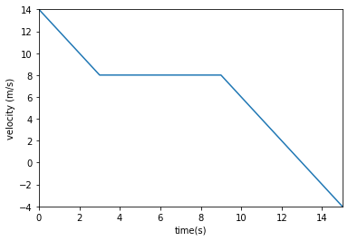

```python
import matplotlib.pyplot as plt
xs = [0, 3, 9, 15]
ys = [14, 8, 8, -4]
plt.axis([0, 15, -4, 14])
plt.plot(xs, ys)
plt.xlabel('time(s)')
plt.ylabel('velocity (m/s)')
plt.show()
```

# 19. Forces and Newton's Laws

Plot a forces diagram.

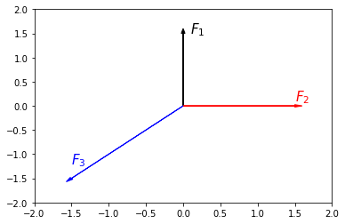

```python
import matplotlib.pyplot as plt
ax = plt.axes()
plt.axis([-2, 2, -2, 2])
ax.arrow(0,0,0,1.5,head_width=0.05,head_length=0.1,fc='k',ec='k')
ax.arrow(0,0,1.5,0,head_width=0.05,head_length=0.1,fc='r',ec='r')
ax.arrow(0,0,-1.5,-1.5,head_width=0.05,head_length=0.1,fc='b',ec='b')
plt.text(0.1,1.5,'$F_1$',fontsize=15)
plt.text(1.5,0.1,'$F_2$',{'color':'red','fontsize':15})
plt.text(-1.5,-1.2,'$F_3$',{'color':'blue','fontsize':15})
plt.show()
```

# 20. Variable Acceleration

Plot a velocity-time graph.

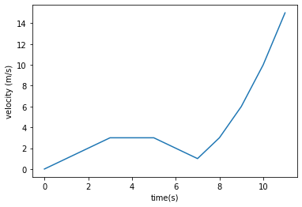

```python
import numpy as np
import matplotlib.pyplot as plt
pts = np.array([0,1,2,3,3,3,2,1,3,6,10,15])
fig = plt.figure()
plt.plot(pts)
plt.xlabel('time(s)')
plt.ylabel('velocity (m/s)')
plt.show()
```

# 21. Proof

(i) For the natural numbers up to 100, investigate when $2n^2$, is close to a perfect square.

This will give a good approximation to $\sqrt{2}$. Can you explain why?

(ii) Prove by elimination, that there is only one solution to the equation:

$m^2-17n^2=1$, where $m$ and $n$ are natural numbers and $1 \leq m \le 500$, $1 \leq n \le 500$.

Print the unique values of $m$ and $n$.

```python
import numpy as np
for n in range(1, 101):
    num1 = np.sqrt(2 * n**2)
    num2 = int(np.round(np.sqrt(2 * n**2)))
    if abs(num1 - num2) < 0.01:
        print(num2, 'divided by', n, 'is approximately sqrt(2)')
```

```
99 divided by 70 is approximately sqrt(2)
140 divided by 99 is approximately sqrt(2)
```

```python
# An example of a program with for loops and if statements.
# The final value, 501, is not included in range in Python.
for m in range(1, 501):
    for n in range(1, 501):
        if m**2 - 17 * n**2 == 1:        # Note the Boolean ==.
            print('The unique solution is, m =',m, 'and n =',n)
```

```
The unique solution is, m = 33 and n = 8
```

# 22. Trigonometry

By plotting curves, show that:

(i) $\sin(t) \approx t$, near $t=0$;

(ii) $\cos(t) \approx 1 - \frac{t^2}{2}$, near $t=0$.

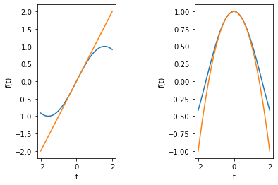

```python
import numpy as np
import matplotlib.pyplot as plt
plt.figure(1)
plt.subplot(121)
t = np.linspace(- 2, 2, 100)
plt.plot(t, np.sin(t), t, t)
plt.xlabel('t')
plt.ylabel('f(t)')
plt.subplot(122)
t = np.linspace(- 2, 2, 100)
plt.plot(t, np.cos(t), t, 1 - t**2 / 2)
plt.xlabel('t')
plt.ylabel('f(t)')
plt.subplots_adjust(wspace=1)
plt.show()
```

# 23. Sequences and Series

Given that, for an arithemtic series:

$a_n=a+(n-1)d$

$S_n=\sum_{i=1}^{n} \, a+(n-1)d$.

Determine:

(i) the term $a_{20}$,

(ii) the sum $S_{20}$,

when $a=3$ and $d=6$.

```python
def nthterm(a, d, n):
    term = a + (n - 1) * d
    return(term)
def sumofAP(a, d, n):
    sum, i = 0, 0
    while i < n:
        sum += a
        a = a + d
        i += 1             # i = i + 1.
    return sum
a, d, n = 3, 6, 20
print('The', n, 'th', 'term is', nthterm(a, d, n))
print('The sum of the', n, 'terms is', sumofAP(a, d, n))
```

```
The 20 th term is 117
The sum of the 20 terms is 1200
```

# 24. Functions

Given that $f(x)=1-x^2$, determine:

(i) $f(2)$;

(ii) $f(f(x))$.

```python
from sympy import expand, Symbol
x = Symbol('x')
def f(x):
    return(1 - x**2)
print('f(x) = ', f(x))
print('f(2) = ', f(2))
print('f(f(x)) = ', expand(f(f(x))))
```

```
f(x) =  1 - x**2
f(2) =  -3
f(f(x)) =  -x**4 + 2*x**2
```

# 25. Differentiation

Given that, $f(x)=\frac{x}{\sqrt{2x-1}}$, determine $\left. \frac{df}{dx} \right|_{x=5}$.

```python
from sympy import diff, sqrt, Symbol
x = Symbol('x')
df = diff(x / sqrt(2 * x - 1), x)
print('df/dx = ', df)
dfx = df.subs(x, 5)
print('Gradient at x = 5 is', dfx)
```

```
df/dx =  -x/(2*x - 1)**(3/2) + 1/sqrt(2*x - 1)
Gradient at x = 5 is 4/27
```

# 26. Trigonometric Functions

Plot the curve $\sec(t)=\frac{1}{\cos(t)}$.

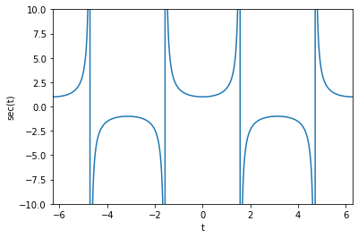

```python
import numpy as np
import matplotlib.pyplot as plt
t = np.linspace(- 2 * np.pi, 2 * np.pi, 1000)
plt.axis([-2 * np.pi, 2 * np.pi, -10, 10])
plt.plot(t, 1 / np.cos(t))
plt.xlabel('t')
plt.ylabel('sec(t)')
plt.show()
```

Solve the trigonometric equation: $2\cos(x) + 5\sin(x)=3$.

```python
from sympy import *
x = Symbol('x')
solve(2 * cos(x) + 5 * sin(x) - 3)
```

```
[2*atan(1 - 2*sqrt(5)/5), 2*atan(2*sqrt(5)/5 + 1)]
```

# 27. Algebra

Split $\frac{2x+3}{(x-2)(x-3)(x-4)}$ into partial fractions.

```python
from sympy import *
x = Symbol('x')
apart((2 * x + 3)/((x - 2) * (x - 3) * (x - 4)))
```

$\displaystyle \frac{7}{2 \left(x - 2\right)} - \frac{9}{x - 3} + \frac{11}{2 \left(x - 4\right)}$

(i) Determine the $O(x^{10})$ Taylor series expansion of $\frac{1}{2-x}$, at $x=0$.

(ii) By plotting curves, show that $\frac{1}{2-x} \approx \frac{1}{2}+\frac{x}{4}+\frac{x^2}{8}$, at $x=0$.

```
The Taylor series of 1/(2-x) is  1/2 + x/4 + x**2/8 + x**3/16 + x**4/32 + x**5/64 + x**6/128 + x**7/256 + x**8/512 + x**9/1024 + O(x**10)
```

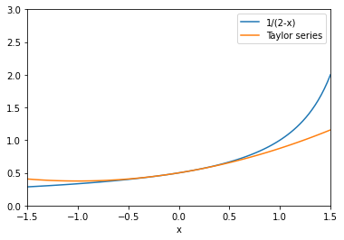

```python
import numpy as np
import matplotlib.pyplot as plt
from sympy import series, Symbol
x = Symbol('x')
Taylor_series = series(1 / (2 - x), x, 0 , 10)
print('The Taylor series of 1/(2-x) is ', Taylor_series)
x = np.linspace(-1.5, 1.5, 100)
plt.axis([-1.5, 1.5, 0, 3])
plt.plot(x, 1/(2 - x), label = '1/(2-x)')
plt.plot(x, 1/2 + x/4 + x**2/8, label = 'Taylor series')
legend = plt.legend()
plt.xlabel('x')
plt.show()
```

# 28. Trigonometric Identities

Show that the curves $f(t)=\sqrt{2}\cos(t)+\sin(t)$, and $g(t)=\sqrt{3}\cos(t-\alpha)$, are equivalent, where $\alpha=\tan^{-1}\left( {\frac{1}{\sqrt{2}}} \right)$.

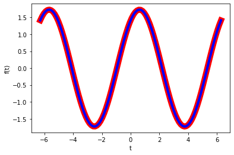

```python
import numpy as np
from sympy import sqrt
from math import atan
import matplotlib.pyplot as plt
alpha = atan(1/sqrt(2))
t = np.linspace(- 2 * np.pi, 2 * np.pi, 100)
plt.plot(t, sqrt(2) * np.cos(t) + np.sin(t), 'r-',linewidth = 10)
plt.plot(t, sqrt(3) * np.cos(t - alpha), 'b-', linewidth = 4)
plt.xlabel('t')
plt.ylabel('f(t)')
plt.show()
```

# 29. Further Differentiation

Differentiate:

(i) $f(x)=3x^2e^{-3x}$;

(ii) $g(x)=\frac{3\sin(x)}{\ln(7x)}$;

(iii) $h(x)=\frac{xe^{-2x}\cos(x)}{(x+1)\sin(x)}$.

```python
from sympy import diff, exp, log, sin, Symbol
x = Symbol('x')
print('df = ', diff(3 * x**2 * exp(- 3 * x), x))
print('dg = ', diff((3*sin(x))/log(7*x)))
print('dh =', diff((x*exp(-2*x)*cos(x)) / ((x+1)*sin(x))))
```

```
df =  -9*x**2*exp(-3*x) + 6*x*exp(-3*x)
dg =  3*cos(x)/log(7*x) - 3*sin(x)/(x*log(7*x)**2)
dh = -x*exp(-2*x)/(x + 1) - 2*x*exp(-2*x)*cos(x)/((x + 1)*sin(x)) - x*exp(-2*x)*cos(x)**2/((x + 1)*sin(x)**2) - x*exp(-2*x)*cos(x)/((x + 1)**2*sin(x)) + exp(-2*x)*cos(x)/((x + 1)*sin(x))
```

# 30. Integration

Integrate:

(i) $I_1 =\int \, x^2\cos(x^3) dx$;

(ii) $I_2 =\int \, x \cos(4x) dx$.

```python
from sympy import cos, integrate, Symbol
x = Symbol('x')
I_1 = integrate(x**2 * cos(x**3), x)
print('I_1=',I_1, '+ c')
I_2 = integrate(x * cos(4 * x), x)
print('I_2=',I_2, '+ k')
```

```
I_1= sin(x**3)/3 + c
I_2= x*sin(4*x)/4 + cos(4*x)/16 + k
```

# 31. Parametric Equations

Plot the parametric curve, $x(t)=1-\cos(t), y(t)=\sin(2t)$, for $0 \leq t \leq 2 \pi$.

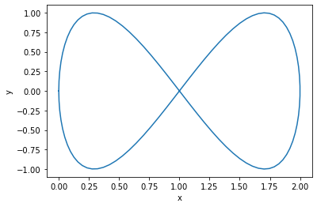

```python
import numpy as np
import matplotlib.pyplot as plt
t = np.linspace(0, 2 * np.pi, 100)
x = 1 - np.cos(t)
y = np.sin(2 * t)
plt.plot(x, y)
plt.xlabel('x')
plt.ylabel('y')
plt.show()
```

# 32. Vectors

Given that $\underline{u}=(1,-1,4)$ and $\underline{v}=(2,-1,9)$, determine:

(i) $5\underline{u}-6\underline{v}$;

(ii) the distance between $\underline{u}$ and $\underline{v}$, $d=\| \underline{u}-\underline{v} \|$.

(iii) the angle, $\theta$, say, between $\underline{u}$ and $\underline{v}$.

Recall that $\cos{\theta}=\frac{\underline{u}.\underline{v}}{\|\underline{u} \| \|\underline{v} \|}$.

```python
import numpy as np
from math import acos
u = np.array([1, -1, 4])
v = np.array([2, -1, 9])
w = 5 * u - 6 * v
print("w =", w)
d = np.linalg.norm(u - v)
print("d =", d)
theta = acos(np.dot(u,v)/(np.linalg.norm(u) * np.linalg.norm(v)))
print('theta =', theta, 'radians')
```

```
w = [ -7   1 -34]
d = 5.0990195135927845
theta = 0.13245459846204063 radians
```

# 33. Differential Equations

(i) Plot the solution to the initial value problem, $\frac{dP}{dt}=P(1-0.01P)$, given that $P(0)=400$. This is a simple population model.

```
P(t) = Eq(P(t), -100.0/(-1.0 + 0.75*exp(-t)))
```

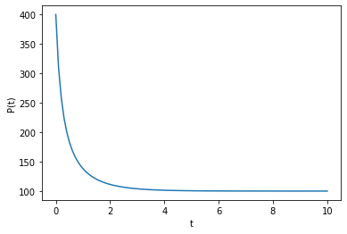

```python
import numpy as np
from sympy import dsolve, Function, symbols
import matplotlib.pyplot as plt
P = Function('P')
t = symbols('t')
ODE = P(t).diff(t) - P(t) * (1 - 0.01 * P(t))
print('P(t) =', dsolve(ODE, ics = {P(0):400}))
t = np.linspace(0, 10, 100)
# Plot the solution to the ODE, P(t).
plt.plot(t, 100.0/(1.0  - 0.75*np.exp(-t)))
plt.xlabel('t')
plt.ylabel('P(t)')
plt.show()
```

(ii) A very simple epidemic model is described by the differential equations:

$\frac{dS}{dt}=-\frac{\beta S I}{N}, \quad \frac{dI}{dt}=\frac{\beta S I}{N} -\gamma I, \quad \frac{dR}{dt}=\gamma I,$

where $S(t)$ is the susceptible population, $I(t)$ is the infected population, $R(t)$ is the recovered-immune population, $N$ is the total population, $\beta$ is the contact rate of the disease and $\gamma$ is the mean recovery rate. Plot the solution curves for $S(t), I(t), R(t)$, given that $N=1000$, $S(0)=999$, $I(0)=1$, $R(0)=0$, $\beta=0.5$ and $\gamma=0.1$. This could be a simple model of the spread of flu in a school.

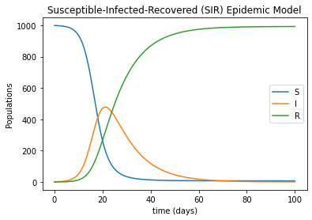

```python
# SIR Epidemic model.
import numpy as np
import matplotlib.pyplot as plt
from scipy.integrate import odeint
# Set the parameters.
beta, gamma = 0.5, 0.1
S0, I0, R0, N = 999, 1, 0, 1000
tmax, n = 100, 1000
def SIR_Model(X, t, beta, gamma):
    S, I, R = X
    dS = - beta * S * I / N
    dI = beta * S * I / N - gamma * I
    dR = gamma * I
    return(dS, dI, dR)
t = np.linspace(0, tmax, n)
f = odeint(SIR_Model, (S0, I0, R0), t, args = (beta, gamma))
S, I, R = f.T
plt.figure(1)
plt.xlabel('time (days)')
plt.ylabel('Populations')
plt.title('Susceptible-Infected-Recovered (SIR) Epidemic Model')
plt.plot(t, S, label = 'S')
plt.plot(t, I, label = 'I')
plt.plot(t, R, label = 'R')
legend = plt.legend(loc = 'best')
plt.show()
```

# 34. Numerical Methods

Use the Newton-Raphson method to find the root of $x^3-0.9x^2+2=0$, starting with the point $x_0=2$. Give your answer to four decimal places. Recall that:

$x_{n+1}=x_n-\frac{f\left(x_n\right)}{f'(x_n)}$.

```python
def fn(x):
    return x**3 - 0.9 * x**2 + 2
def dfn(x):
    return 3 * x**2 - 1.8 * x
def NewtonRaphson(x):
    i = 0
    h = fn(x) / dfn(x)
    while abs(h) >= 0.0001:
        h = fn(x) / dfn(x)
        x = x - h
        i += 1              # i = i + 1
        print('x(', i ,')', 'is {:6.4f}.'.format(x))
# Start at x( 0 ) = 2.
NewtonRaphson(2)
```

```
x( 1 ) is 1.2381.
x( 2 ) is 0.1756.
x( 3 ) is 9.0222.
x( 4 ) is 6.1131.
x( 5 ) is 4.1665.
x( 6 ) is 2.8496.
x( 7 ) is 1.9224.
x( 8 ) is 1.1648.
x( 9 ) is -0.0307.
x( 10 ) is -34.4718.
x( 11 ) is -22.8835.
x( 12 ) is -15.1594.
x( 13 ) is -10.0129.
x( 14 ) is -6.5872.
x( 15 ) is -4.3139.
x( 16 ) is -2.8196.
x( 17 ) is -1.8664.
x( 18 ) is -1.3134.
x( 19 ) is -1.0722.
x( 20 ) is -1.0225.
x( 21 ) is -1.0205.
x( 22 ) is -1.0205.
```

# 35. Probability

Generate some random data in Python and compare the histogram to a normal probability distribution function. Deremine the mean and standard deviation of the data.

```
Mean = 427.4599332718842
Standard Deviation = 443.7026959303684
```

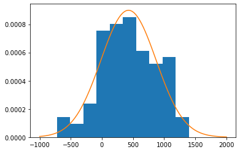

```python
from scipy import stats
import numpy as np
import matplotlib.pyplot as plt
data = 50 * np.random.rand() * np.random.normal(10, 10, 100) + 20
plt.hist(data, density = True)
xt = plt.xticks()[0]
xmin, xmax = min(xt), max(xt)
lnspc = np.linspace(xmin, xmax, len(data))
m, s = stats.norm.fit(data)
pdf_g = stats.norm.pdf(lnspc, m, s)
plt.plot(lnspc, pdf_g)
print('Mean =', m)
print('Standard Deviation =', s)
plt.show()
```

# 36. Probablility Distributions

The normal probability density function (PDF) is an example of a continuous PDF.

The general form of a normal distribution is:

$f(x)=\frac{1}{\sigma \sqrt{2 \pi}} e^{-\frac{1}{2} \left(\frac{x-\mu}{\sigma} \right)^2 }$,

where $\mu$ is the mean or expectation of the distribution, $\sigma^2$, is the variance, amd $\sigma$ is the standard deviation.

Example: Suppose that $X$ is normally distributed with a mean of 80 and a standard deviation of 4. So, $X \sim N(80, 16)$. Plot the bell curve and determine:

(a) $P(X<75)$; (b) $P(X>83)$; (c) $P(72<X<76)$.

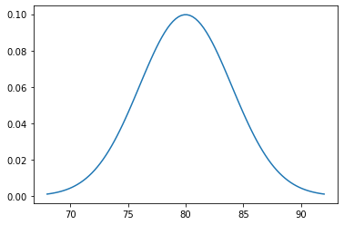

```
P(X<75)= 0.10564977366685535
P(X>83)= 0.22662735237686826
P(72<X<76)= 0.13590512198327787
```

```python
import matplotlib.pyplot as plt
import numpy as np
import scipy.stats as stats
import math

mu , variance = 80 , 4**2
sigma = math.sqrt(variance)
x = np.linspace(mu - 3*sigma, mu + 3*sigma, 100)
plt.plot(x, stats.norm.pdf(x, mu, sigma))
plt.show()

sola = stats.norm.cdf(75, loc=mu, scale=sigma)
print('P(X<75)=', sola)

solb = 1 - stats.norm.cdf(83, loc=mu, scale=sigma)
print('P(X>83)=', solb)

solc = stats.norm.cdf(76, loc=mu, scale=sigma) - \
       stats.norm.cdf(72, loc=mu, scale=sigma)
print('P(72<X<76)=', solc)
```

# 37. Hypothesis Testing

Example: The diameters of circular cardboard drinks packs produced by a certain machine are normally distributed with a mean of 9cm and standard deviation of 0.15cm. After the machine is serviced a random sample of 30 mats is selected and their diameters are measured to see if the mean diameter has altered.

The mean of the sample was 8.95cm. Test at the 5% level, whether there is significant evidence of a change in the mean diameter of mats produced by the machine.

Now, the null hypothesis is, $H_0: \mu=9$,

The alternative hypothesis is, $H_1: \mu \neq 9$. (Two-tailed test)

See below. Since $P(X<=8.95)=0.033945>0.025$, accept $H_0$.

There is not enough evidence to suggest there has been a change in the mean diamater of the mats.

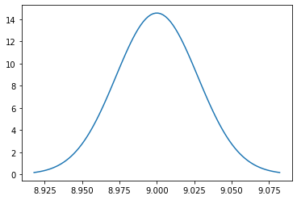

```
P(X<=8.95)= 0.033944577430912545
```

```python
import matplotlib.pyplot as plt
import numpy as np
import scipy.stats as stats
import math

mu , variance = 9 , 0.15**2 / 30
sigma = math.sqrt(variance)
x = np.linspace(mu - 3*sigma, mu + 3*sigma, 100)
plt.plot(x, stats.norm.pdf(x, mu, sigma))
plt.show()

sol = stats.norm.cdf(8.95, loc=mu, scale=sigma)
print('P(X<=8.95)=', sol)
```

# 38. Kinematics

Given that, $\underline{u}=2\underline{i}+9\underline{j} \, ms^{-1}$, $\underline{a}=-9.8\underline{j} \, ms^{-2}$, and $t=0.2s$, show that the distance travelled is $\underline{s}=0.4\underline{i}+1.604\underline{j} \, m$.

Recall that:

$\underline{v}=\underline{u}+\underline{a}t$;

$\underline{v}^2=\underline{u}^2+2\underline{a}\, \underline{s}$;

$\underline{s}=\underline{u}t+\frac{1}{2}\underline{a}t^2$;

$\underline{s}=(\underline{u}+\underline{v}) \frac{t}{2}$.

```python
import numpy as np
u = np.array([2, 9])
a = np.array([0, -9.8])
t = 0.2
s = u * t + a * t**2 / 2
print('Distance travelled =', s, 'm')
```

```
Distance travelled = [0.4   1.604] m
```

# 39. Forces and Motion

```python
import numpy as np
FAx = 0
FAy = -20
FBx = -16 * np.sin(np.radians(40.8))
FBy = -16 * np.cos(np.radians(40.8))
FR = np.array([FAx + FBx, FAy + FBy])
FR_norm = np.linalg.norm(FR)
FR_angle = np.degrees(np.arctan(FR[1] / FR[0]))
print("FR =", FR_norm, "N")
print("FR Angle =", FR_angle, "degrees.")
```

```
FR = 33.77094662009231 N
FR Angle = 71.96622155260425 degrees.
```

# 40. Moments

Given that, $F_1=5$N, $F_2=2$N, where would a force of $F_3=3$N need to be placed to balance the beam?

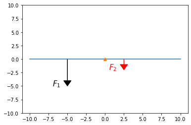

```python
import matplotlib.pyplot as plt
ax = plt.axes()
plt.plot([-10, 10], [0, 0])
plt.axis([-11, 11, -10, 10])
plt.plot([0], marker = "^")
ax.arrow(-5, 0, 0, -4, head_width = 1, head_length = 1, fc = 'k', ec = 'k')
ax.arrow(2.5, 0, 0, -1, head_width = 1, head_length = 1, fc = 'r', ec = 'r')
plt.text(-7, -5, '$F_1$', fontsize = 15)
plt.text(0.5, -2, '$F_2$', {'color': 'red', 'fontsize':15})
plt.show()
```

# 41. Projectiles

Plot the trajectory of a ball thrown from the top of a cliff. The ball is thrown from the top of a cliff of height $10$ metres with velocity $\underline{u}=20\sqrt{3}\underline{i}+20\underline{j} \, ms^{-1}$. Use the equation:

$\underline{s}=\underline{u}t+\frac{1}{2}\underline{a}t^2$.

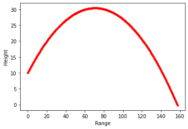

```python
import numpy as np
import matplotlib.pyplot as plt
x0, y0, sy, g, dt, t = 0, 10, 0, 9.8, 0.01, 0
vx0 = 20 * np.sqrt(3)
vy0 = 20
while sy >= 0:
    sx = vx0 * t
    sy = vy0 * t - g * t**2 / 2 + y0
    t = t + dt
    plt.plot(sx, sy, 'r.')
plt.xlabel('Range')
plt.ylabel('Height')
plt.show()
```

# 42. Friction

Determine the acceleration of the particle up the slope, given that the coefficient of friction, $\mu$ say, is $\mu=\frac{1}{4}$.

[figure not shown]

```python
import numpy as np
# Resolve forces normal to slope.
R = 25 * 9.8 * np.cos(np.radians(25)) - 300 * np.sin(np.radians(15))
print("R =", R, "N")
# Since particle is moving.
F = (1 / 4) * R
print("F =", F, "N")
# Resolve forces parallel to slope.
a_num = 300 * np.cos(np.radians(15)) - F - 25 * 9.8 * np.sin(np.radians(25))
a = a_num / 25
print('a =', a, 'm/s/s.')
```

```
R = 144.39969429322304 N
F = 36.09992357330576 N
a = 6.005454007477733 m/s/s.
```

# Python Books by Dr Stephen Lynch NTF FIMA SFHEA

[figure not shown]

CRC Press (2024): https://www.routledge.com/A-Simple-Introduction-to-Python/Lynch/p/book/9781032750293

Support Material

GitHub Repository of Data Files and a Jupyter Solution notebook:

https://github.com/proflynch/A-Simple-Introduction-to-Python

Jupyter Solution notebook web page:

https://drstephenlynch.github.io/webpages/A-Simple-Introduction-to-Python-Solutions.html

[figure not shown]

CRC Press (2023): https://www.routledge.com/Python-for-Scientific-Computing-and-Artificial-Intelligence/Lynch/p/book/9781032258713#

Support Material

GitHub Repository of Python Files and Notebooks:

https://github.com/proflynch/CRC-Press/

Solutions to All Exercises:

Section 1: An Introduction to Python:

https://drstephenlynch.github.io/webpages/Solutions_Section_1.html

Section 2: Python for Scientific Computing:

https://drstephenlynch.github.io/webpages/Solutions_Section_2.html

Section 3: Artificial Intelligence:

https://drstephenlynch.github.io/webpages/Solutions_Section_3.html

[figure not shown]

Springer International Publishing (2018):

http://www.springer.com/us/book/9783319781440

Jupyter Notebook:

https://drstephenlynch.github.io/webpages/DSAP_Jupyter_Notebook.html

GitHub Files:

https://github.com/springer-math/dynamical-systems-with-applications-using-python